# Week 9: Lab - Using aRules on the Titanic dataset

## Step 3.2 - Function 2

Write a function, using the previous function, that calculates the percentage (who lives, who dies) for specified (parameters) classes. The function passes four arguments. Calculating percentage means that the number of observations that meets the criteria (values of the specified classes) divided by the entire number of observations.

```r
percent_calc <- function(class,sex,age,survive){
  filter_df <- create_DF(class,sex,age,survive)
  filter_count <- nrow(filter_df)
  percentage <- round((filter_count / total_count) * 100)
  return(percentage)
}
```

```r
example_survive <- percent_calc("1st", "Female", "Adult", "Yes")
example_survive
```

```
## [1] 6
```

```r
example_death <- percent_calc("3rd", "Male", "Adult", "Yes")
example_death
```

```
## [1] 3
```

## Step 3.3 - Use the function (male)

Use the function to compare age and third-class male survival rates.

```r
third_child_survive <- percent_calc("3rd", "Male", "Child", "Yes")
third_child_survive
```

```
## [1] 1
```

```r
third_adult_survive <- percent_calc("3rd", "Male", "Adult", "Yes")
third_adult_survive
```

```
## [1] 3
```

People in which category are more likely to survive?

> More male adults in 3rd class survived the Titanic disaster than male children in 3rd class.

## Step 3.4 - Use the function (female)

Use the function to compare age and first-class female survival rates.

```r
first_child_survive <- percent_calc("1st", "Female", "Child", "Yes")
first_child_survive
```

```
## [1] 0
```

```r
first_adult_survive <- percent_calc("1st", "Female", "Adult", "Yes")
first_adult_survive
```

```
## [1] 6
```

People in which category are more likely to survive?

# Step 4 - Use aRules

1. Use aRules to calculate some rules (clusters) for the titanic dataset. set support threshold as 0.005, and confidence as 0.5. Show only rhs=(“Survived=Yes”). Read the documentation to investigate “appearance”
2. Visualize the results.
3. Pick the three most interesting and useful rules (a. pick rules whose lift is higher than 2, b. sort the good rules by “lift”). Explain these rules using natural language. **Answer this in the space provided below.**
4. How does this compare to the descriptive analysis we did on the same data set? Think critically. What was possible using one method that was not possible using the other method? **Answer this in the space provided below.**

```r
t_trans <- as(tdata, "transactions")
rules <- apriori(t_trans, parameter = list(support = 0.005, confidence = 0.5), appearance = list(rhs = c("Survived=Yes")))
```

[output not shown]

[output not shown]

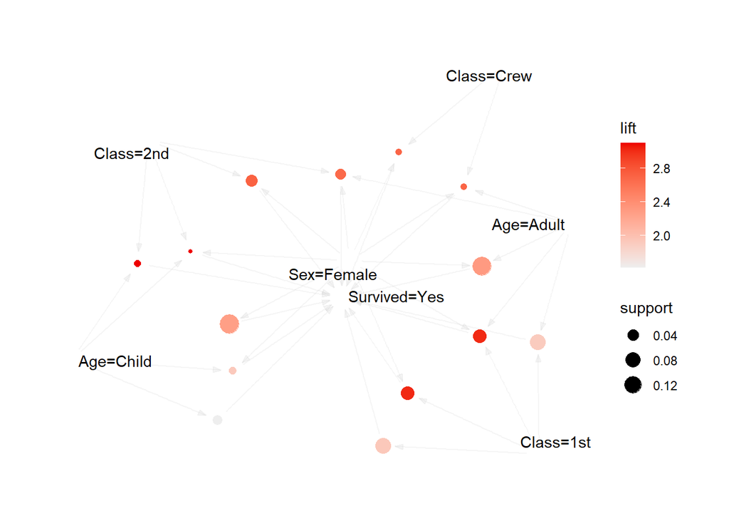

```r
plot(rules, method = "graph", control = list(type = "items"))
```

**Answer part 3 and 4 below.**

> Interestingly, the three most impactful rules regarding the data include the age of the survivor being a child, the sex of the survivor being a female, and the fact they survived in the first place. While the aRules graph is a decent visual adaptation of the data in the Titanic dataset, I feel the previous method of calculating percentages was a lot more informative, as it produced results that were a lot more clear and easy to understand than the info that the graph itself presents.